# Ford GoBike System Data Exploration

## by Mustapha Olalekan Alaba

## Introduction

> This data set includes information about individual rides made in a bike-sharing system covering the greater San Francisco Bay area for the month of February 2019.

## Preliminary Wrangling

```python
# import all packages and set plots to be embedded inline
import numpy as np
import pandas as pd
import matplotlib.pyplot as plt
import seaborn as sb

%matplotlib inline

# suppress warnings from final output
import warnings
warnings.simplefilter("ignore")
```

```python
# load in the dataset into a pandas dataframe, print statistics
gobike = pd.read_csv('201902-fordgobike-tripdata.csv', parse_dates=['start_time', 'end_time'])
```

```python
# high-level overview of data shape and composition
print(gobike.shape)
print(gobike.dtypes)
print(gobike.head(10))
```

```
(183412, 16)
duration_sec                        int64
start_time                 datetime64[ns]
end_time                   datetime64[ns]
start_station_id                  float64
start_station_name                 object
start_station_latitude            float64
start_station_longitude           float64
end_station_id                    float64
end_station_name                   object
end_station_latitude              float64
end_station_longitude             float64
bike_id                             int64
user_type                          object
member_birth_year                 float64
member_gender                      object
bike_share_for_all_trip            object
dtype: object
   duration_sec              start_time                end_time  \
0         52185 2019-02-28 17:32:10.145 2019-03-01 08:01:55.975
1         42521 2019-02-28 18:53:21.789 2019-03-01 06:42:03.056
2         61854 2019-02-28 12:13:13.218 2019-03-01 05:24:08.146
3         36490 2019-02-28 17:54:26.010 2019-03-01 04:02:36.842
4          1585 2019-02-28 23:54:18.549 2019-03-01 00:20:44.074
5          1793 2019-02-28 23:49:58.632 2019-03-01 00:19:51.760
6          1147 2019-02-28 23:55:35.104 2019-03-01 00:14:42.588
7          1615 2019-02-28 23:41:06.766 2019-03-01 00:08:02.756
8          1570 2019-02-28 23:41:48.790 2019-03-01 00:07:59.715
9          1049 2019-02-28 23:49:47.699 2019-03-01 00:07:17.025

   start_station_id                                start_station_name  \
0              21.0  Montgomery St BART Station (Market St at 2nd St)
1              23.0                     The Embarcadero at Steuart St
2              86.0                           Market St at Dolores St
3             375.0                           Grove St at Masonic Ave
4               7.0                               Frank H Ogawa Plaza
5              93.0                      4th St at Mission Bay Blvd S
6             300.0                              Palm St at Willow St
7              10.0                        Washington St at Kearny St
8              10.0                        Washington St at Kearny St
```

[output cut: 34 more lines]

```
7            -122.421025     6329  Subscriber             1989.0
8            -122.421025     6548  Subscriber             1988.0
9            -122.421339     6488  Subscriber             1992.0

  member_gender bike_share_for_all_trip
0          Male                      No
1           NaN                      No
2          Male                      No
3         Other                      No
4          Male                     Yes
5          Male                      No
6        Female                      No
7          Male                      No
8         Other                      No
9          Male                      No
```

```python
# check missing values
gobike.isna().sum()
```

```
duration_sec                  0
start_time                    0
end_time                      0
start_station_id            197
start_station_name          197
start_station_latitude        0
start_station_longitude       0
end_station_id              197
end_station_name            197
end_station_latitude          0
end_station_longitude         0
bike_id                       0
user_type                     0
member_birth_year          8265
member_gender              8265
bike_share_for_all_trip       0
dtype: int64
```

```python
# filter records with missing station inf0
missing_stations_filter =  gobike['start_station_id'].isna() | gobike['end_station_id'].isna()
gobike = gobike[~missing_stations_filter]
gobike
```

|  | duration_sec | start_time | end_time | start_station_id | start_station_name | start_station_latitude | start_station_longitude | end_station_id | end_station_name | end_station_latitude | end_station_longitude | bike_id | user_type | member_birth_year | member_gender | bike_share_for_all_trip |
| --- | --- | --- | --- | --- | --- | --- | --- | --- | --- | --- | --- | --- | --- | --- | --- | --- |
| 0 | 52185 | 2019-02-28 17:32:10.145 | 2019-03-01 08:01:55.975 | 21.0 | Montgomery St BART Station (Market St at 2nd St) | 37.789625 | -122.400811 | 13.0 | Commercial St at Montgomery St | 37.794231 | -122.402923 | 4902 | Customer | 1984.0 | Male | No |
| 1 | 42521 | 2019-02-28 18:53:21.789 | 2019-03-01 06:42:03.056 | 23.0 | The Embarcadero at Steuart St | 37.791464 | -122.391034 | 81.0 | Berry St at 4th St | 37.775880 | -122.393170 | 2535 | Customer | NaN | NaN | No |
| 2 | 61854 | 2019-02-28 12:13:13.218 | 2019-03-01 05:24:08.146 | 86.0 | Market St at Dolores St | 37.769305 | -122.426826 | 3.0 | Powell St BART Station (Market St at 4th St) | 37.786375 | -122.404904 | 5905 | Customer | 1972.0 | Male | No |
| 3 | 36490 | 2019-02-28 17:54:26.010 | 2019-03-01 04:02:36.842 | 375.0 | Grove St at Masonic Ave | 37.774836 | -122.446546 | 70.0 | Central Ave at Fell St | 37.773311 | -122.444293 | 6638 | Subscriber | 1989.0 | Other | No |
| 4 | 1585 | 2019-02-28 23:54:18.549 | 2019-03-01 00:20:44.074 | 7.0 | Frank H Ogawa Plaza | 37.804562 | -122.271738 | 222.0 | 10th Ave at E 15th St | 37.792714 | -122.248780 | 4898 | Subscriber | 1974.0 | Male | Yes |
| ... | ... | ... | ... | ... | ... | ... | ... | ... | ... | ... | ... | ... | ... | ... | ... | ... |
| 183407 | 480 | 2019-02-01 00:04:49.724 | 2019-02-01 00:12:50.034 | 27.0 | Beale St at Harrison St | 37.788059 | -122.391865 | 324.0 | Union Square (Powell St at Post St) | 37.788300 | -122.408531 | 4832 | Subscriber | 1996.0 | Male | No |
| 183408 | 313 | 2019-02-01 00:05:34.744 | 2019-02-01 00:10:48.502 | 21.0 | Montgomery St BART Station (Market St at 2nd St) | 37.789625 | -122.400811 | 66.0 | 3rd St at Townsend St | 37.778742 | -122.392741 | 4960 | Subscriber | 1984.0 | Male | No |
| 183409 | 141 | 2019-02-01 00:06:05.549 | 2019-02-01 00:08:27.220 | 278.0 | The Alameda at Bush St | 37.331932 | -121.904888 | 277.0 | Morrison Ave at Julian St | 37.333658 | -121.908586 | 3824 | Subscriber | 1990.0 | Male | Yes |
| 183410 | 139 | 2019-02-01 00:05:34.360 | 2019-02-01 00:07:54.287 | 220.0 | San Pablo Ave at MLK Jr Way | 37.811351 | -122.273422 | 216.0 | San Pablo Ave at 27th St | 37.817827 | -122.275698 | 5095 | Subscriber | 1988.0 | Male | No |
| 183411 | 271 | 2019-02-01 00:00:20.636 | 2019-02-01 00:04:52.058 | 24.0 | Spear St at Folsom St | 37.789677 | -122.390428 | 37.0 | 2nd St at Folsom St | 37.785000 | -122.395936 | 1057 | Subscriber | 1989.0 | Male | No |

183215 rows × 16 columns

```python
# fill missing gender with NA
gobike["member_gender"].fillna('NA', inplace=True)
```

```python
#add start_day column to dataset
gobike['start_day'] = gobike.start_time.dt.day_of_week
```

```python
gobike.describe()
```

|  | duration_sec | start_station_id | start_station_latitude | start_station_longitude | end_station_id | end_station_latitude | end_station_longitude | bike_id | member_birth_year | start_day |
| --- | --- | --- | --- | --- | --- | --- | --- | --- | --- | --- |
| count | 183215.000000 | 183215.000000 | 183215.000000 | 183215.000000 | 183215.000000 | 183215.000000 | 183215.000000 | 183215.000000 | 174952.000000 | 183215.000000 |
| mean | 725.902017 | 138.590427 | 37.771615 | -122.353104 | 136.249123 | 37.771820 | -122.352689 | 4473.218792 | 1984.803135 | 2.632306 |
| std | 1795.078654 | 111.778864 | 0.098914 | 0.116387 | 111.515131 | 0.098819 | 0.115961 | 1665.249372 | 10.118731 | 1.814510 |
| min | 61.000000 | 3.000000 | 37.317298 | -122.453704 | 3.000000 | 37.317298 | -122.453704 | 11.000000 | 1878.000000 | 0.000000 |
| 25% | 325.000000 | 47.000000 | 37.770407 | -122.412408 | 44.000000 | 37.770407 | -122.411726 | 3777.000000 | 1980.000000 | 1.000000 |
| 50% | 514.000000 | 104.000000 | 37.780760 | -122.398285 | 100.000000 | 37.781010 | -122.398279 | 4958.000000 | 1987.000000 | 3.000000 |
| 75% | 796.000000 | 239.000000 | 37.797280 | -122.287180 | 235.000000 | 37.797320 | -122.288665 | 5503.000000 | 1992.000000 | 4.000000 |
| max | 85444.000000 | 398.000000 | 37.880222 | -121.874119 | 398.000000 | 37.880222 | -121.874119 | 6645.000000 | 2001.000000 | 6.000000 |

### What is the structure of your dataset?

> There are total of 183412 bike ride record with 16 features. 197 of the rides records are missing the start and end station information. 8,265 of the records are missing the riders member_birth_year and member_gender information.

> float feature: start_station_latitude, start_station_longitude, end_station_latitude, end_station_longitude

> String Feature: start_station_name, end_station_name

> Datetime: start_time, end_time

> Categorical: user_type, member_gender, bike_share_for_all_trip

### What is/are the main feature(s) of interest in your dataset?

> I'm quite interested in figuring out When are most trips taken in terms of time of day and day of the week accross all station and by gender?

### What features in the dataset do you think will help support your investigation into your feature(s) of interest?

> Start time, end time and Gender. I am suspecting more rides will be taking during the weekdays and by male gender. I also think that most rides will be in the morning and evenings not during daytime for weekdays and more rides will happen during work hour at weekends.

## Univariate Exploration

#### How are rides distributed accross day of the weeks

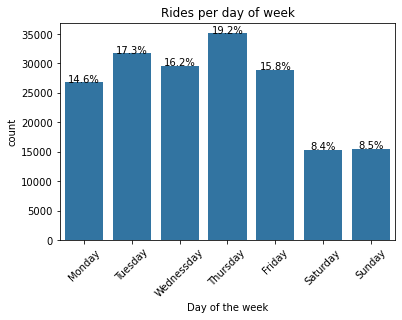

```python
base_color = sb.color_palette()[0]
day_of_week  = ['Monday', 'Tuesday', 'Wednessday', 'Thursday', "Friday", "Saturday", "Sunday"]
sb.countplot(data=gobike, x=gobike.start_time.dt.day_of_week, color=base_color)
plt.xticks(np.arange(0,7), day_of_week, rotation='45')
plt.xlabel('Day of the week')
plt.title('Rides per day of week')


day_of_week_counts = gobike.start_time.dt.day_of_week.value_counts()
total_counts = day_of_week_counts.sum()

#print the proportion text on the bars
for i in range (day_of_week_counts.shape[0]):

    count = day_of_week_counts.loc[i]
    # Convert count into a percentage, and then into string
    pct_string = '{:0.1f}%'.format(100*count/total_counts)
    # Print the string value on the bar.
    plt.text(i, count, pct_string, ha='center')
plt.show()
```

Our assumption of having more rides during the weekdays is clearly shown in the above chart, we can now take a look at the overall distribution of rides accross hours of the day

We will start with a bin size equivalent to every 30mins from Midnight

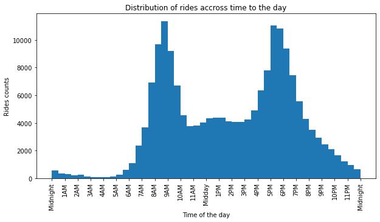

```python
# extracting time as a new feature in float between 0 and 24 to see hour trips are distributed during the day.
gobike['hour_of_the_day'] = gobike.start_time.dt.hour + gobike.start_time.dt.minute/60
bins = np.arange(0, gobike['hour_of_the_day'].max()+0.5, 0.5)
def time_of_hist(data, bins):
    plt.figure(figsize=[10, 5])
    plt.hist(data = data, x = 'hour_of_the_day', bins = bins)
    xticks_time = ["Midnight","1AM","2AM","3AM","4AM","5AM","6AM","7AM","8AM","9AM","10AM","11AM","Midday","1PM","2PM","3PM","4PM","5PM","6PM","7PM","8PM","9PM","10PM","11PM","Midnight"]
    plt.xticks(range(0,25), xticks_time, rotation=90)
    plt.xlabel("Time of the day")
    plt.ylabel("Rides counts")
    plt.title("Distribution of rides accross time to the day")
    plt.show()

time_of_hist(gobike, bins)
```

lets' see an hourly bin size equivalent

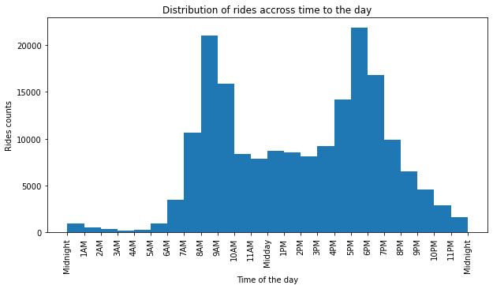

```python
bins = np.arange(0, gobike['hour_of_the_day'].max()+0.5, 1)
time_of_hist(gobike, bins)
```

From above we notice we have two peak time first one between 8am and 9am, also between 5pm and 6pm. There is also a slight increase in rides taken between midday and 1:30pm. Next we will look at the distribution of ride time.

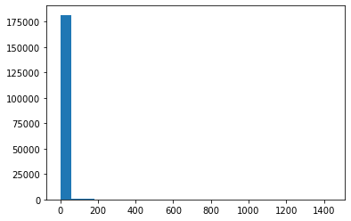

```python
# let's create addtional features for duration in minutes
gobike['duration_min'] = gobike['duration_sec'] / 60

# All records using a binsize 60 - a minute
binsize = 60
bins = np.arange(0, gobike['duration_min'].max()+binsize, binsize)
plt.hist(data=gobike, x='duration_min', bins=bins)
plt.show()
```

#### We see that the rides look right skewed and have some significantly very high ride time. Let us separate rides that take longer than an hour and plot a new histogram

```
No     181509
Yes      1706
Name: above_1hr, dtype: int64
```

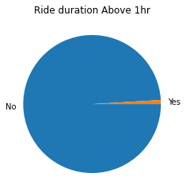

```python
# we see that the rides look ride skewed and have some significantly very high ride time
above_1hr_filter = gobike["duration_min"] > 60

gobike.loc[above_1hr_filter, 'above_1hr'] = 'Yes'
gobike.loc[~above_1hr_filter, 'above_1hr'] = 'No'
above_1hr_counts = gobike['above_1hr'].value_counts()

print(above_1hr_counts)
plt.pie(above_1hr_counts, labels = above_1hr_counts.index, counterclock = False);
plt.title("Ride duration Above 1hr")
plt.show()
```

The above shows that the data contains some outliers that should be separated for some of our findings. We will reproduced our histogram to see how the rides under 1hour are distributed

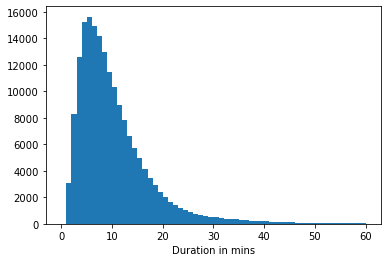

```python
# All records using a binsize 60 - a minute
gobike = gobike[gobike['duration_min'] <= 60]

binsize = 1
bins = np.arange(0, gobike['duration_min'].max()+binsize, binsize)
plt.hist(data = gobike, x = 'duration_min', bins = bins);
plt.xlabel("Duration in mins")
plt.show()
```

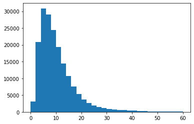

```python
# investigating using a binsize 2 minutes

binsize = 2
bins = np.arange(0, gobike['duration_min'].max()+binsize, binsize)
plt.hist(data = gobike, x = 'duration_min', bins = bins);
plt.show()
```

We can further investigate to see if transforming the histogram give further insights.

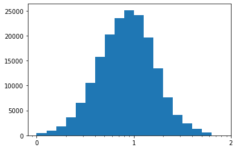

```python
# investigating using a binsize 2 minutes

log_binsize = 0.1
bins = 10 ** np.arange(0, np.log10(gobike['duration_min'].max())+log_binsize, log_binsize)
plt.hist(data = gobike, x = 'duration_min', bins = bins);
plt.xscale('log')
plt.xticks([1,10,100], [0,1,2])
plt.show()
```

The log transformation shows that this is a Log-normal distribution.

## How is the dataset is divided among genders?

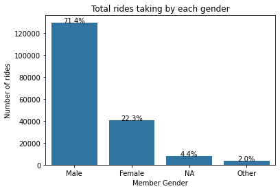

```python
# Where gender are missing, we will represent it as NotApplicable - NA
member_gender_counts = gobike["member_gender"].value_counts()

sb.countplot(data=gobike, x='member_gender', color=base_color, order=member_gender_counts.index)
# plt.xticks(np.arange(0,7), day_of_week, rotation='45')
plt.xlabel('Member Gender')
plt.ylabel('Number of rides')
plt.title('Total rides taking by each gender')


total_gender_counts = member_gender_counts.sum()

# #print the proportion text on the bars
for i in range (member_gender_counts.shape[0]):

    count = member_gender_counts[i]
    # Convert count into a percentage, and then into string
    pct_string = '{:0.1f}%'.format(100*count/total_gender_counts)
    # Print the string value on the bar.
    plt.text(i, count, pct_string, ha='center')
# plt.show()
```

The Male gender rides alot compare to others, it will be good to further explore maybe the percentage participation have any significant changes between hour of the day, weekdays and weekends.

### Discuss the distribution(s) of your variable(s) of interest. Were there any unusual points? Did you need to perform any transformations?

The duration variable took on a large range of values, so I looked at the data using a log transform. Under the transformation, the data looked symetrical giving a normal distribution.

### Of the features you investigated, were there any unusual distributions? Did you perform any operations on the data to tidy, adjust, or change the form of the data? If so, why did you do this?

When investigating the duration variable, all rides that took longer than an hour was consider as outlier and the dataset contain 1706 of such rides. When plotting the histogram and moving forward the focus was then adjusted to rides that have maximum duration of an hour. The reason for such high ride time should be a separate investigation.

## How are the day of the week when compared with duration in minutes?

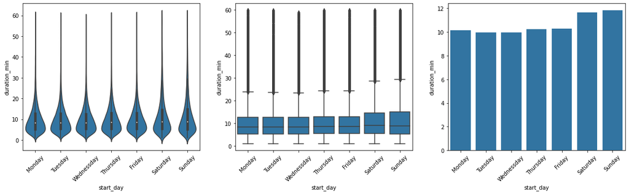

```python
plt.figure(figsize = [20, 5])
base_color = sb.color_palette()[0]

# left plot: violin plot
plt.subplot(1, 3, 1)
sb.violinplot(data=gobike, x='start_day', y='duration_min', inner = 'box',
              color = base_color)
plt.xticks(np.arange(0,7), day_of_week, rotation='45')


# center plot: box plot
plt.subplot(1, 3, 2)
sb.boxplot(data=gobike, x='start_day', y='duration_min',  color = base_color)
plt.xticks(np.arange(0,7), day_of_week, rotation='45')


# right plot: adapted bar chart
plt.subplot(1, 3, 3)
sb.barplot(data=gobike, x='start_day', y='duration_min',  color = base_color, ci=None)
plt.xticks(np.arange(0,7), day_of_week, rotation='45')
plt.show()
```

We will notice that, the week days Monday - Friday, roughly have same average ride duration of 10mins and same range while the weekends have higher average duration (almost 12mins) and range. For both the weekdays and weekends, there are outliers, starting at 25mins for weekdays and roughly 30mins for weekends.

### How are rides distributed accross the hour of the day by gender?

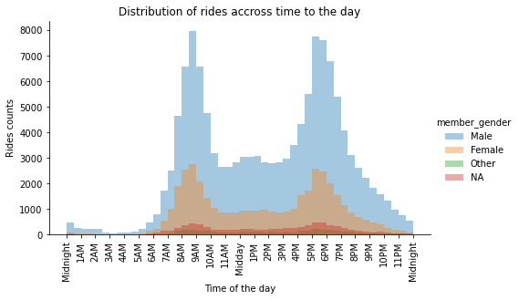

```python
 bin_edges = np.arange(0, gobike['hour_of_the_day'].max()+0.5, 0.5)
g = sb.FacetGrid(data = gobike, hue = 'member_gender', height = 4, aspect=1.65)
g.map(plt.hist, "hour_of_the_day", bins = bin_edges, alpha=.4)
g.add_legend()

xticks_time = ["Midnight","1AM","2AM","3AM","4AM","5AM","6AM","7AM","8AM","9AM","10AM","11AM","Midday","1PM","2PM","3PM","4PM","5PM","6PM","7PM","8PM","9PM","10PM","11PM","Midnight"]
plt.xticks(range(0,25), xticks_time, rotation=90)
plt.xlabel("Time of the day")
plt.ylabel("Rides counts")
plt.title("Distribution of rides accross time to the day")
plt.show()
```

To have a clearer picture of what is happening, we can dig further by splitting each day on a different historgram

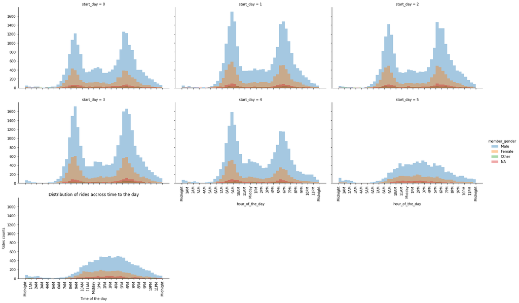

```python
bin_edges = np.arange(0, gobike['hour_of_the_day'].max()+0.5, 0.5)
g = sb.FacetGrid(data = gobike, hue = 'member_gender', col="start_day", col_wrap=3 ,height = 4, aspect=1.65)
g.map(plt.hist, "hour_of_the_day", bins = bin_edges, alpha=.4)
g.add_legend()

xticks_time = ["Midnight","1AM","2AM","3AM","4AM","5AM","6AM","7AM","8AM","9AM","10AM","11AM","Midday","1PM","2PM","3PM","4PM","5PM","6PM","7PM","8PM","9PM","10PM","11PM","Midnight"]

for axes in g.axes.flat:
    _ = axes.set_xticklabels(axes.get_xticklabels(), rotation=90)

plt.xticks(range(0,25), xticks_time, rotation=90)
plt.xlabel("Time of the day")
plt.ylabel("Rides counts")
plt.title("Distribution of rides accross time to the day")
plt.show()
```

From the above we see that for monday, wednesday and thursday, there are closely same number of rides taking at the morning and evening peak while for Tuesday and Friday day, there is a significant difference between the morning peak and evening peaks. Midday ride peak varies for each day of Monday to friday, tuesday being close to a uniform distribution at midday day. Weekends differs totally showing a normal distribution starting from 7AM to Midgnight for Saturday and sundays

### Is there any significant changes in ride participation by gender for each day of the week?

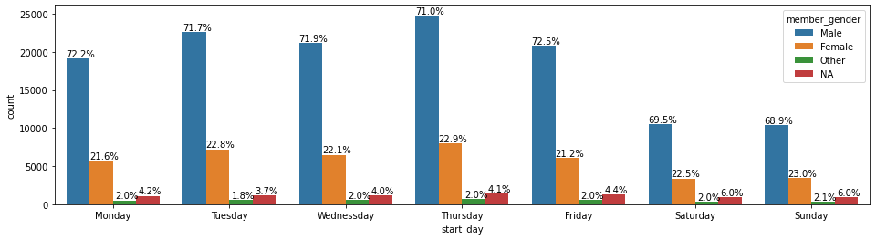

```python
plt.figure(figsize = [16, 4])

ax = sb.countplot(data = gobike, x = 'start_day', hue = 'member_gender')

totals = gobike.groupby('start_day')['start_time'].count()
plt.xticks(np.arange(0,7), day_of_week, rotation='0')

# create tabular form for bar heights
bars_height = []
for i in range(4):
    ind = i*7
    p_heights = [p.get_height() for p in ax.patches[ind:ind+7]]
    bars_height.append(p_heights)

# use pandas to get % from tabular form for bar heights
height_df = pd.DataFrame(bars_height)
height_df_percent = (100. * height_df / height_df.sum()).round(1).astype(str) + '%'

for i in range(4):
    ind = i*7
    for p_ind, p in enumerate(ax.patches[ind:ind+7]):
        x = p.get_x() + 0.12
        y = p.get_height()
        ax.annotate(height_df_percent.loc[i][p_ind], (x, y), ha='center', va='bottom')
```

For weekdays, the male percentage was around 71-72% but drops below 70% for saturdays and sundays. other gender have slight increase in percentage for weekends.

### Talk about some of the relationships you observed in this part of the investigation. How did the feature(s) of interest vary with other features in the dataset?

The number of rides which is determined by the start time have an average duration of 10mins during the weekdays and 12mins for weekends. It is also noticed that while the Male gender percentage rides decrease during the weekend other gender increases. The distirbution of rides during the weekdays model similar patterns for all genders but different for weekends.

### Did you observe any interesting relationships between the other features (not the main feature(s) of interest)?

The average duration for rides during the week roughly 10mins while for weekeends it get higher to 12mins

## Multivariate Exploration

### How does user_type affect rides duratoin?

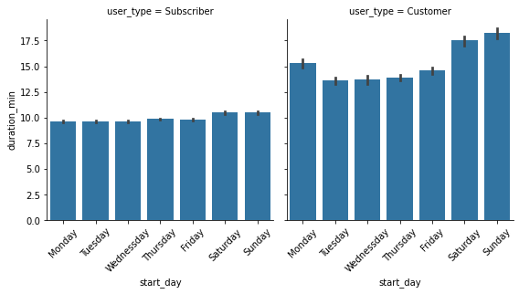

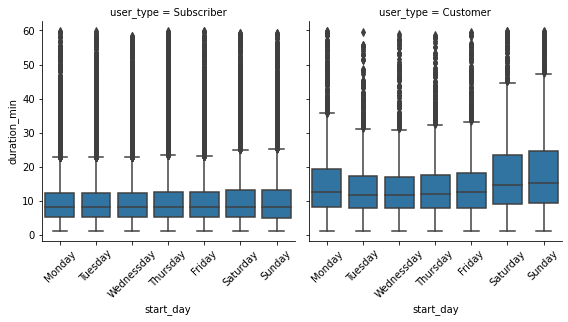

```python
g = sb.FacetGrid(data = gobike, col = 'user_type', height = 4)
g.map(sb.barplot, 'start_day', 'duration_min', order=range(0,7))
plt.xticks(np.arange(0,7), day_of_week, rotation='45')
for axes in g.axes.flat:
    _ = axes.set_xticklabels(axes.get_xticklabels(), rotation=45)
plt.show()

g = sb.FacetGrid(data = gobike, col = 'user_type', height = 4)
g.map(sb.boxplot, 'start_day', 'duration_min', order=range(0,7))
plt.xticks(np.arange(0,7), day_of_week, rotation='45')
for axes in g.axes.flat:
    _ = axes.set_xticklabels(axes.get_xticklabels(), rotation=45)
plt.show()
```

It will be observed that the average rides duration for Subscribers is closely 10mins. Customer user type have higher average ride duration which stays roughly the same for Tuesday through Thursday at about 14mins having higher duration for Monday and Fridays and evn higher on weekends.

### Does the distribution of rides at different hours of the day differ for each user type?

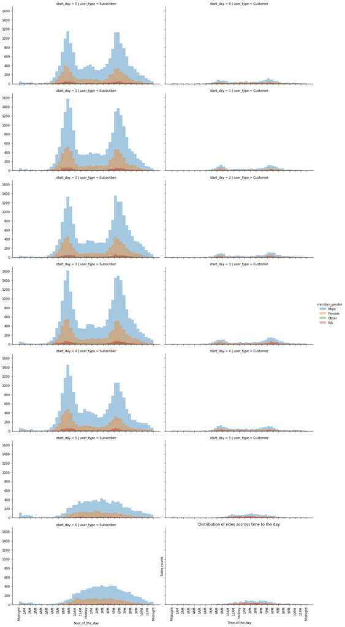

```python
bin_edges = np.arange(0, gobike['hour_of_the_day'].max()+0.5, 0.5)
g = sb.FacetGrid(data = gobike, hue = 'member_gender', col="user_type", row='start_day', height = 4, aspect=1.8)
g.map(plt.hist, "hour_of_the_day", bins = bin_edges, alpha=.4)
g.add_legend()

xticks_time = ["Midnight","1AM","2AM","3AM","4AM","5AM","6AM","7AM","8AM","9AM","10AM","11AM","Midday","1PM","2PM","3PM","4PM","5PM","6PM","7PM","8PM","9PM","10PM","11PM","Midnight"]

for axes in g.axes.flat:
    _ = axes.set_xticklabels(axes.get_xticklabels(), rotation=90)

plt.xticks(range(0,25), xticks_time, rotation=90)
plt.xlabel("Time of the day")
plt.ylabel("Rides counts")
plt.title("Distribution of rides accross time to the day")
plt.show()
```

The customer are few but rides longer and don't start riding early like the subscribers. they also don't ride late compare to the subscribers.

### Talk about some of the relationships you observed in this part of the investigation. Were there features that strengthened each other in terms of looking at your feature(s) of interest?

The subscriber user type have rides for 10mins on average while the Customer have higher average time and ride longer during the weekends. The majority of the trips are done by the subscriber.

### Were there any interesting or surprising interactions between features?

The customer are few but rides longer and don't start riding early like the subscribers. they also don't ride late compare to the subscribers.

## Conclusions

The rides are dominated by male genders, but during the weekends other gender have an increased in percentage of the overall rides. The peak period during the weekdays happens in the morning hour of 8am-9am and in the evening 5pm to 6pm. They is also slight increas in rides count between midday and 1pm. Although the major rides are done by the subscriber with roughly average of 10mins ride duration, the rides done by customers have higher average duration of ride for weekday and even more during the weekends